# Part II - Effects of Loan features on Estimated Effective Yield

## Dataset Overview

> The dataset contained 81 variables and 113937 observations. The dataset was accompanied by a CSV that had variable definitions to make it easy to understand the variables. The dataset is available [here](https://s3.amazonaws.com/udacity-hosted-downloads/ud651/prosperLoanData.csv)

```python
from IPython.display import HTML

HTML('''<script>
code_show=true;
function code_toggle() {
 if (code_show){
 $('div.input').hide();
 } else {
 $('div.input').show();
 }
 code_show = !code_show
}
$( document ).ready(code_toggle);
</script>
<form action="javascript:code_toggle()"><input type="submit" value="Click here to toggle on/off the raw code."></form>''')
```

## Estimated Effective Yield

> **EstimatedEffectiveYield** is the Yield of lenders from borrowers minus the processing fee and late fines

> The distribution of Estimated Effective Yield is multimodial, with several peaks. Clearly very few to no loans have a effective yield past 0.35

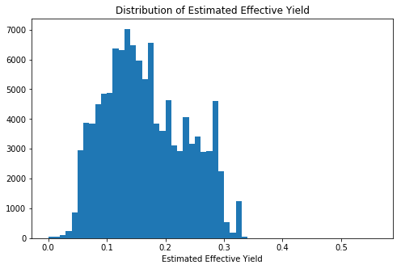

```python
plt.figure(figsize=[8,5])
base_color = sb.color_palette()[0]
bins = np.arange(0, df.BorrowerAPR.max()+0.05,0.01)
plt.hist(data=df, x='EstimatedEffectiveYield', bins = bins,color=base_color);
plt.xlabel('Estimated Effective Yield');
plt.title('Distribution of Estimated Effective Yield');
```

## Loan Original Amount

> **Loan Original Amount** - this is basically the original amount of loan the borrower borrows

> There are are large spikes around 5000,10000,15000,20000 and 25000. Which potrays that most people take loans of these amounts more compared to other amounts

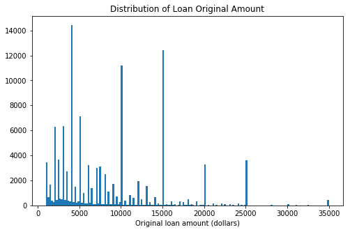

```python
max_amount = df.LoanOriginalAmount.max()
bins = np.arange(1000, max_amount+200, 200)
plt.figure(figsize=[8, 5])
plt.hist(data = df, x = 'LoanOriginalAmount', bins = bins);
plt.xlabel('Original loan amount (dollars)');
plt.title('Distribution of Loan Original Amount');
```

## Prosper Score VS Estimated Effective Yield

> A higher Prosper score depicts a better borrower and a lower prosper score depicts a not-so-good borrower. From the plot we notice how the white dot, which is the median of estimated effective yield, drops as the Prosper score increases. This means lenders allow better interest rates to borrowers with higher rating. I best believe this acts as an incentive to keep them.

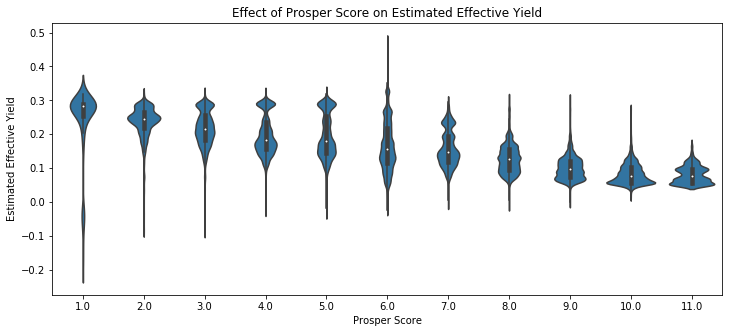

```python
plt.figure(figsize=[12,5])
base_color = sb.color_palette()[0]
sb.violinplot(data = df, y='EstimatedEffectiveYield',x='ProsperScore', color=base_color);
plt.title('Effect of Prosper Score on Estimated Effective Yield');
plt.xlabel('Prosper Score')
plt.ylabel('Estimated Effective Yield');
```

## Do bigger loans enjoy lesser interest rates(effective yield)?

> The regplot shows that as the Loan amount increases, the Effective yield decreases, however it is important to note the difference is slight and not as drastic.

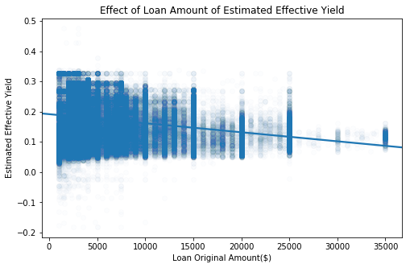

```python
plt.figure(figsize=[8,5])
sb.regplot(data = df, y='EstimatedEffectiveYield',x='LoanOriginalAmount', scatter_kws={'alpha':0.01});
plt.title('Effect of Loan Amount of Estimated Effective Yield');
plt.xlabel('Loan Original Amount($)')
plt.ylabel('Estimated Effective Yield');
```

## Effect of Prosper Score on the relationship between loan amount and effective yield

> It is clear that better prosper score decreases the effective yield but increases the Loan amount. Lesser score have higher effective yield and lesser loan amounts.

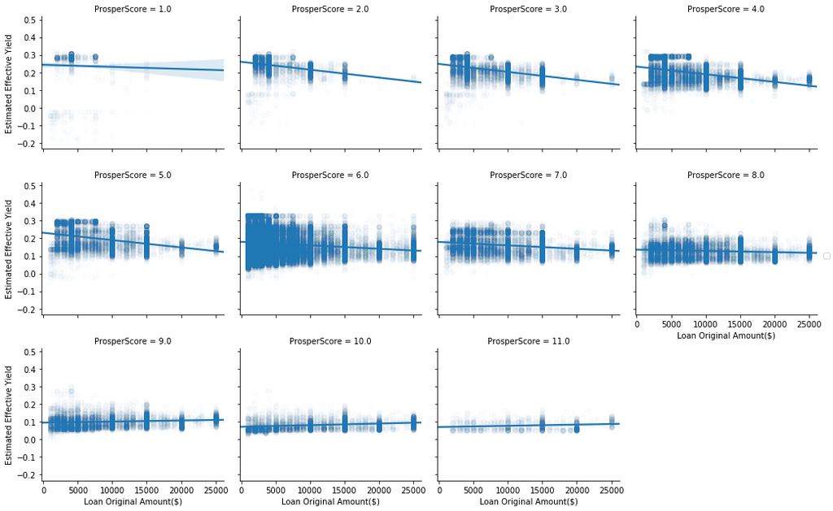

```python
g=sb.FacetGrid(data=df, aspect=1.2,col='ProsperScore', col_wrap=4)
g.map(sb.regplot, 'LoanOriginalAmount', 'EstimatedEffectiveYield', x_jitter=0.04, scatter_kws={'alpha':0.01});
g.add_legend();
g.set_axis_labels('Loan Original Amount($)');
g.set_ylabels('Estimated Effective Yield');
```